# Group 32: Predicting Life Expectancy Using Several Variables.

Group members: Jiawei Huang, Wanying Zheng, Lucy Liu, Cong Cheng, Effie Wang

## Introduction

Over the past century, the development and improvement of healthcare service, education, and living standards have become important factors in the global rise of life expectancy (O'Connor, 2022). However, there are more factors that affect life expectancy. Life expectancy is a very important and distinct measure that summarizes the overall health of a comunnity. According to a study that investigates mortality rate in separated age groups, the mortality rate of children younger than 5 years decreased from 1970 to 2016 while the mortality rate of adult deaths increased in each 5-year age bracket above the age of 25 years (MacroTrends, n.d.). In contrast to earlier decades, the distribution of annualized rates of change in age-specific mortality rates was different from 2000 to 2016 (MacroTrends, n.d.).

By understanding and gaining more insight from the relationship between life expectancy and its determining factors, health institutes and governments can consider more aspects when they decide how to improve people' life span.

Our study will investigate influences from economy, immunization, and diseases on life expectancy. We aim to build a strong predictive model to predict life expectancy based on some input variables.

#### Dataset

We're considering our sample to be what is available here https://www.kaggle.com/datasets/kumarajarshi/life-expectancy-who?resource=download

**Life.expectancy:** Life Expectancy in age

One potential impact is that our model could help with health institute. By monitoring a region's data, health institutes can make plan to help improve people's life expectancy. Increase in life expectancy can benefit a region's economy because people live longer and able to work longer.

## Exploratory Data Analysis

First, we install necessary packages and load libraries.

```r
install.packages("Metrics")
```

```r
library(Metrics)
library(mltools)
library(leaps)
library(glmnet)
library(cowplot)
library(broom)
```

```r
library(car)
```

```r
library(tidyverse)
```

```r
#library(tidyverse)
library(digest)
library(plyr)
library(repr)
library(GGally)
```

```r
# set seed
SEED <- 996
set.seed(SEED)
```

```r
# read data
life <- read.csv("Life Expectancy Data.csv")
```

```r
# take a look at data
nrow(life)
head(life)
tail(life) # original data: 22 columns
```

2938

A data.frame: 6 × 22

|  | Country <chr> | Year <int> | Status <chr> | Life.expectancy <dbl> | Adult.Mortality <int> | infant.deaths <int> | Alcohol <dbl> | percentage.expenditure <dbl> | Hepatitis.B <int> | Measles <int> | ⋯ | Polio <int> | Total.expenditure <dbl> | Diphtheria <int> | HIV.AIDS <dbl> | GDP <dbl> | Population <dbl> | thinness..1.19.years <dbl> | thinness.5.9.years <dbl> | Income.composition.of.resources <dbl> | Schooling <dbl> |
| --- | --- | --- | --- | --- | --- | --- | --- | --- | --- | --- | --- | --- | --- | --- | --- | --- | --- | --- | --- | --- | --- |
| 1 | Afghanistan | 2015 | Developing | 65.0 | 263 | 62 | 0.01 | 71.279624 | 65 | 1154 | ⋯ | 6 | 8.16 | 65 | 0.1 | 584.25921 | 33736494 | 17.2 | 17.3 | 0.479 | 10.1 |
| 2 | Afghanistan | 2014 | Developing | 59.9 | 271 | 64 | 0.01 | 73.523582 | 62 | 492 | ⋯ | 58 | 8.18 | 62 | 0.1 | 612.69651 | 327582 | 17.5 | 17.5 | 0.476 | 10.0 |
| 3 | Afghanistan | 2013 | Developing | 59.9 | 268 | 66 | 0.01 | 73.219243 | 64 | 430 | ⋯ | 62 | 8.13 | 64 | 0.1 | 631.74498 | 31731688 | 17.7 | 17.7 | 0.470 | 9.9 |
| 4 | Afghanistan | 2012 | Developing | 59.5 | 272 | 69 | 0.01 | 78.184215 | 67 | 2787 | ⋯ | 67 | 8.52 | 67 | 0.1 | 669.95900 | 3696958 | 17.9 | 18.0 | 0.463 | 9.8 |
| 5 | Afghanistan | 2011 | Developing | 59.2 | 275 | 71 | 0.01 | 7.097109 | 68 | 3013 | ⋯ | 68 | 7.87 | 68 | 0.1 | 63.53723 | 2978599 | 18.2 | 18.2 | 0.454 | 9.5 |
| 6 | Afghanistan | 2010 | Developing | 58.8 | 279 | 74 | 0.01 | 79.679367 | 66 | 1989 | ⋯ | 66 | 9.20 | 66 | 0.1 | 553.32894 | 2883167 | 18.4 | 18.4 | 0.448 | 9.2 |

A data.frame: 6 × 22

|  | Country <chr> | Year <int> | Status <chr> | Life.expectancy <dbl> | Adult.Mortality <int> | infant.deaths <int> | Alcohol <dbl> | percentage.expenditure <dbl> | Hepatitis.B <int> | Measles <int> | ⋯ | Polio <int> | Total.expenditure <dbl> | Diphtheria <int> | HIV.AIDS <dbl> | GDP <dbl> | Population <dbl> | thinness..1.19.years <dbl> | thinness.5.9.years <dbl> | Income.composition.of.resources <dbl> | Schooling <dbl> |
| --- | --- | --- | --- | --- | --- | --- | --- | --- | --- | --- | --- | --- | --- | --- | --- | --- | --- | --- | --- | --- | --- |
| 2933 | Zimbabwe | 2005 | Developing | 44.6 | 717 | 28 | 4.14 | 8.717409 | 65 | 420 | ⋯ | 69 | 6.44 | 68 | 30.3 | 444.76575 | 129432 | 9.0 | 9.0 | 0.406 | 9.3 |
| 2934 | Zimbabwe | 2004 | Developing | 44.3 | 723 | 27 | 4.36 | 0.000000 | 68 | 31 | ⋯ | 67 | 7.13 | 65 | 33.6 | 454.36665 | 12777511 | 9.4 | 9.4 | 0.407 | 9.2 |
| 2935 | Zimbabwe | 2003 | Developing | 44.5 | 715 | 26 | 4.06 | 0.000000 | 7 | 998 | ⋯ | 7 | 6.52 | 68 | 36.7 | 453.35116 | 12633897 | 9.8 | 9.9 | 0.418 | 9.5 |
| 2936 | Zimbabwe | 2002 | Developing | 44.8 | 73 | 25 | 4.43 | 0.000000 | 73 | 304 | ⋯ | 73 | 6.53 | 71 | 39.8 | 57.34834 | 125525 | 1.2 | 1.3 | 0.427 | 10.0 |
| 2937 | Zimbabwe | 2001 | Developing | 45.3 | 686 | 25 | 1.72 | 0.000000 | 76 | 529 | ⋯ | 76 | 6.16 | 75 | 42.1 | 548.58731 | 12366165 | 1.6 | 1.7 | 0.427 | 9.8 |
| 2938 | Zimbabwe | 2000 | Developing | 46.0 | 665 | 24 | 1.68 | 0.000000 | 79 | 1483 | ⋯ | 78 | 7.10 | 78 | 43.5 | 547.35888 | 12222251 | 11.0 | 11.2 | 0.434 | 9.8 |

**Table 1: Raw Data**

```r
# Checking if dataset contains any null values
# check for missing data
colSums(is.na(life))
```

**Country**

0

**Year**

0

**Status**

0

**Life.expectancy**

10

**Adult.Mortality**

10

**infant.deaths**

0

**Alcohol**

194

**percentage.expenditure**

0

**Hepatitis.B**

553

**Measles**

0

**BMI**

34

**under.five.deaths**

0

**Polio**

19

**Total.expenditure**

226

**Diphtheria**

19

**HIV.AIDS**

0

**GDP**

448

**Population**

652

**thinness..1.19.years**

34

**thinness.5.9.years**

34

**Income.composition.of.resources**

167

**Schooling**

163

```r
life_tidy <- na.omit(life)
```

```r
nrow(life_tidy)
```

1649

We remove rows with NA value. We have 1649 observations left.

Since the `thinness..1.19.years` and `thinness.5.9.years` columns from the original data set are very similar in meaning, so we modify these 2 columns into 1 column `thinness.5.19.years`by taking average of them.

```r
# combine 2 columns into 1:
life_tidy <- life_tidy %>%
mutate(thinness.5.19.years = (thinness..1.19.years + thinness.5.9.years)/2) %>%
subset(select = -c(thinness..1.19.years,thinness.5.9.years))
head(life_tidy)  # 21 columns (input + response)
```

A data.frame: 6 × 21

|  | Country <chr> | Year <int> | Status <chr> | Life.expectancy <dbl> | Adult.Mortality <int> | infant.deaths <int> | Alcohol <dbl> | percentage.expenditure <dbl> | Hepatitis.B <int> | Measles <int> | ⋯ | under.five.deaths <int> | Polio <int> | Total.expenditure <dbl> | Diphtheria <int> | HIV.AIDS <dbl> | GDP <dbl> | Population <dbl> | Income.composition.of.resources <dbl> | Schooling <dbl> | thinness.5.19.years <dbl> |
| --- | --- | --- | --- | --- | --- | --- | --- | --- | --- | --- | --- | --- | --- | --- | --- | --- | --- | --- | --- | --- | --- |
| 1 | Afghanistan | 2015 | Developing | 65.0 | 263 | 62 | 0.01 | 71.279624 | 65 | 1154 | ⋯ | 83 | 6 | 8.16 | 65 | 0.1 | 584.25921 | 33736494 | 0.479 | 10.1 | 17.25 |
| 2 | Afghanistan | 2014 | Developing | 59.9 | 271 | 64 | 0.01 | 73.523582 | 62 | 492 | ⋯ | 86 | 58 | 8.18 | 62 | 0.1 | 612.69651 | 327582 | 0.476 | 10.0 | 17.50 |
| 3 | Afghanistan | 2013 | Developing | 59.9 | 268 | 66 | 0.01 | 73.219243 | 64 | 430 | ⋯ | 89 | 62 | 8.13 | 64 | 0.1 | 631.74498 | 31731688 | 0.470 | 9.9 | 17.70 |
| 4 | Afghanistan | 2012 | Developing | 59.5 | 272 | 69 | 0.01 | 78.184215 | 67 | 2787 | ⋯ | 93 | 67 | 8.52 | 67 | 0.1 | 669.95900 | 3696958 | 0.463 | 9.8 | 17.95 |
| 5 | Afghanistan | 2011 | Developing | 59.2 | 275 | 71 | 0.01 | 7.097109 | 68 | 3013 | ⋯ | 97 | 68 | 7.87 | 68 | 0.1 | 63.53723 | 2978599 | 0.454 | 9.5 | 18.20 |
| 6 | Afghanistan | 2010 | Developing | 58.8 | 279 | 74 | 0.01 | 79.679367 | 66 | 1989 | ⋯ | 102 | 66 | 9.20 | 66 | 0.1 | 553.32894 | 2883167 | 0.448 | 9.2 | 18.40 |

**Table 2: Data with Column Modified**

We also remove the column `Country` because they are just names and identities, including them will create many dummy variables and add burden to our computation.

```r
life_tidy <- select(life_tidy, -Country)
```

```r
colnames(life_tidy) # 20 variables total (input + response)
```

1. 'Year'

2. 'Status'

3. 'Life.expectancy'

4. 'Adult.Mortality'

5. 'infant.deaths'

6. 'Alcohol'

7. 'percentage.expenditure'

8. 'Hepatitis.B'

9. 'Measles'

10. 'BMI'

11. 'under.five.deaths'

12. 'Polio'

13. 'Total.expenditure'

14. 'Diphtheria'

15. 'HIV.AIDS'

16. 'GDP'

17. 'Population'

18. 'Income.composition.of.resources'

19. 'Schooling'

20. 'thinness.5.19.years'

After column modification and removal, we have these 20 columns left for analysis.

```r
head(life_tidy)  # 20 columns (19 input, 1 response)
```

A data.frame: 6 × 20

|  | Year <int> | Status <chr> | Life.expectancy <dbl> | Adult.Mortality <int> | infant.deaths <int> | Alcohol <dbl> | percentage.expenditure <dbl> | Hepatitis.B <int> | Measles <int> | BMI <dbl> | under.five.deaths <int> | Polio <int> | Total.expenditure <dbl> | Diphtheria <int> | HIV.AIDS <dbl> | GDP <dbl> | Population <dbl> | Income.composition.of.resources <dbl> | Schooling <dbl> | thinness.5.19.years <dbl> |
| --- | --- | --- | --- | --- | --- | --- | --- | --- | --- | --- | --- | --- | --- | --- | --- | --- | --- | --- | --- | --- |
| 1 | 2015 | Developing | 65.0 | 263 | 62 | 0.01 | 71.279624 | 65 | 1154 | 19.1 | 83 | 6 | 8.16 | 65 | 0.1 | 584.25921 | 33736494 | 0.479 | 10.1 | 17.25 |
| 2 | 2014 | Developing | 59.9 | 271 | 64 | 0.01 | 73.523582 | 62 | 492 | 18.6 | 86 | 58 | 8.18 | 62 | 0.1 | 612.69651 | 327582 | 0.476 | 10.0 | 17.50 |
| 3 | 2013 | Developing | 59.9 | 268 | 66 | 0.01 | 73.219243 | 64 | 430 | 18.1 | 89 | 62 | 8.13 | 64 | 0.1 | 631.74498 | 31731688 | 0.470 | 9.9 | 17.70 |
| 4 | 2012 | Developing | 59.5 | 272 | 69 | 0.01 | 78.184215 | 67 | 2787 | 17.6 | 93 | 67 | 8.52 | 67 | 0.1 | 669.95900 | 3696958 | 0.463 | 9.8 | 17.95 |
| 5 | 2011 | Developing | 59.2 | 275 | 71 | 0.01 | 7.097109 | 68 | 3013 | 17.2 | 97 | 68 | 7.87 | 68 | 0.1 | 63.53723 | 2978599 | 0.454 | 9.5 | 18.20 |
| 6 | 2010 | Developing | 58.8 | 279 | 74 | 0.01 | 79.679367 | 66 | 1989 | 16.7 | 102 | 66 | 9.20 | 66 | 0.1 | 553.32894 | 2883167 | 0.448 | 9.2 | 18.40 |

**Table 3: Tidied Data**

```r
tibble(number_of_columns = ncol(life_tidy))
```

A tibble: 1 × 1

| number_of_columns <int> |
| --- |
| 20 |

**Table 4: Number of Columns in Data**

Let's take a look at the distribution of the response variable `Life.expectancy`

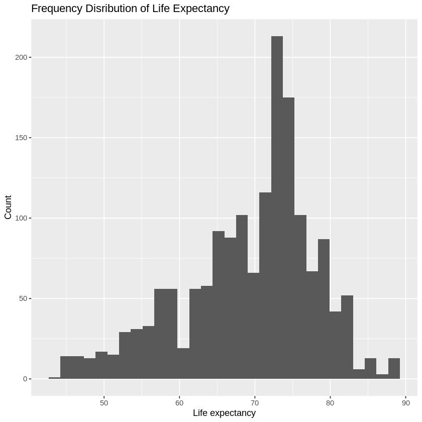

```r
# visualize response variable: Life.expectancy
options(repr.plot.width = 7,repr.plot.height=7)
life_tidy %>% ggplot(aes(x = Life.expectancy)) +
    geom_histogram(bins = 30) +
    xlab("Life expectancy") +
    ylab("Count") +
    ggtitle("Frequency Disribution of Life Expectancy")
```

**Figure 1: Histogram of Response Variable, Life Expectancy**

From Figure 1, the distribution of life expectancy is approximately normal, and very slightly skew to the left.

```r
# identify numeric variables vs categorical variables.
str(life_tidy)
```

```
'data.frame':	1649 obs. of  20 variables:
 $ Year                           : int  2015 2014 2013 2012 2011 2010 2009 2008 2007 2006 ...
 $ Status                         : chr  "Developing" "Developing" "Developing" "Developing" ...
 $ Life.expectancy                : num  65 59.9 59.9 59.5 59.2 58.8 58.6 58.1 57.5 57.3 ...
 $ Adult.Mortality                : int  263 271 268 272 275 279 281 287 295 295 ...
 $ infant.deaths                  : int  62 64 66 69 71 74 77 80 82 84 ...
 $ Alcohol                        : num  0.01 0.01 0.01 0.01 0.01 0.01 0.01 0.03 0.02 0.03 ...
 $ percentage.expenditure         : num  71.3 73.5 73.2 78.2 7.1 ...
 $ Hepatitis.B                    : int  65 62 64 67 68 66 63 64 63 64 ...
 $ Measles                        : int  1154 492 430 2787 3013 1989 2861 1599 1141 1990 ...
 $ BMI                            : num  19.1 18.6 18.1 17.6 17.2 16.7 16.2 15.7 15.2 14.7 ...
 $ under.five.deaths              : int  83 86 89 93 97 102 106 110 113 116 ...
 $ Polio                          : int  6 58 62 67 68 66 63 64 63 58 ...
 $ Total.expenditure              : num  8.16 8.18 8.13 8.52 7.87 9.2 9.42 8.33 6.73 7.43 ...
 $ Diphtheria                     : int  65 62 64 67 68 66 63 64 63 58 ...
 $ HIV.AIDS                       : num  0.1 0.1 0.1 0.1 0.1 0.1 0.1 0.1 0.1 0.1 ...
 $ GDP                            : num  584.3 612.7 631.7 670 63.5 ...
 $ Population                     : num  33736494 327582 31731688 3696958 2978599 ...
 $ Income.composition.of.resources: num  0.479 0.476 0.47 0.463 0.454 0.448 0.434 0.433 0.415 0.405 ...
 $ Schooling                      : num  10.1 10 9.9 9.8 9.5 9.2 8.9 8.7 8.4 8.1 ...
 $ thinness.5.19.years            : num  17.2 17.5 17.7 17.9 18.2 ...
```

```r
# numeric
numeric_variables <- life_tidy %>% select(-Status)
```

```r
# categorical
categorical_variables <- life_tidy %>% select(Status)
```

```r
# change categorical column from char type to factor
is.factor(life_tidy$Status)
```

FALSE

We change the categorical variable from char type to factor.

```r
life_tidy$Status <- as.factor(life_tidy$Status)
```

```r
is.factor(life_tidy$Status)
```

TRUE

```r
n_nv <- ncol(numeric_variables)
n_cv <- ncol(categorical_variables)
tibble(number_of_numeric_variables = n_nv,number_of_categorical_variables = n_cv)
```

A tibble: 1 × 2

| number_of_numeric_variables <int> | number_of_categorical_variables <int> |
| --- | --- |
| 19 | 1 |

**Table 5: Number of Numeric and Categorical Variables in Data**

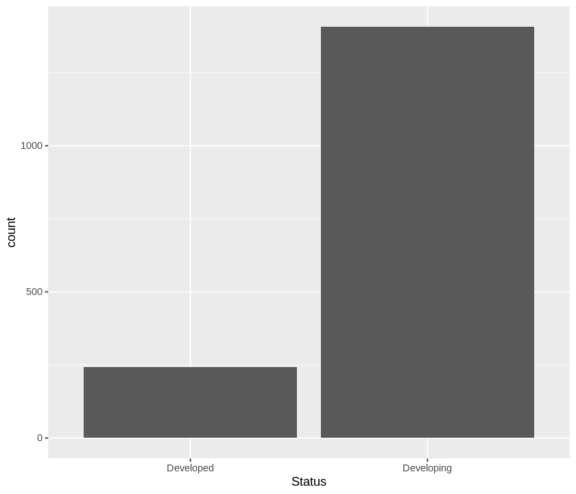

```r
# visualize categorical variable:
options(repr.plot.width = 7,repr.plot.height=6)
ggplot(life_tidy, aes(x =Status)) +
  geom_bar()
```

**Figure 2: Countplot of Categorical Variable, Status**

From Figure 2, we see that the number of data points with Status=Developing are much more than the number of data points with Status=Developed. There is imbalance in data.

We use ggpairs to explore the numeric input variables' relations with each other by plotting scattorplots between all numeric variables.

```r
# ggpairs

pair_plots <- numeric_variables %>%
  select(-Life.expectancy) %>%  # not include response
  ggpairs(progress = FALSE) +
  theme(
    text = element_text(size = 15),
    plot.title = element_text(face = "bold"),
    axis.title = element_text(face = "bold")
  )
```

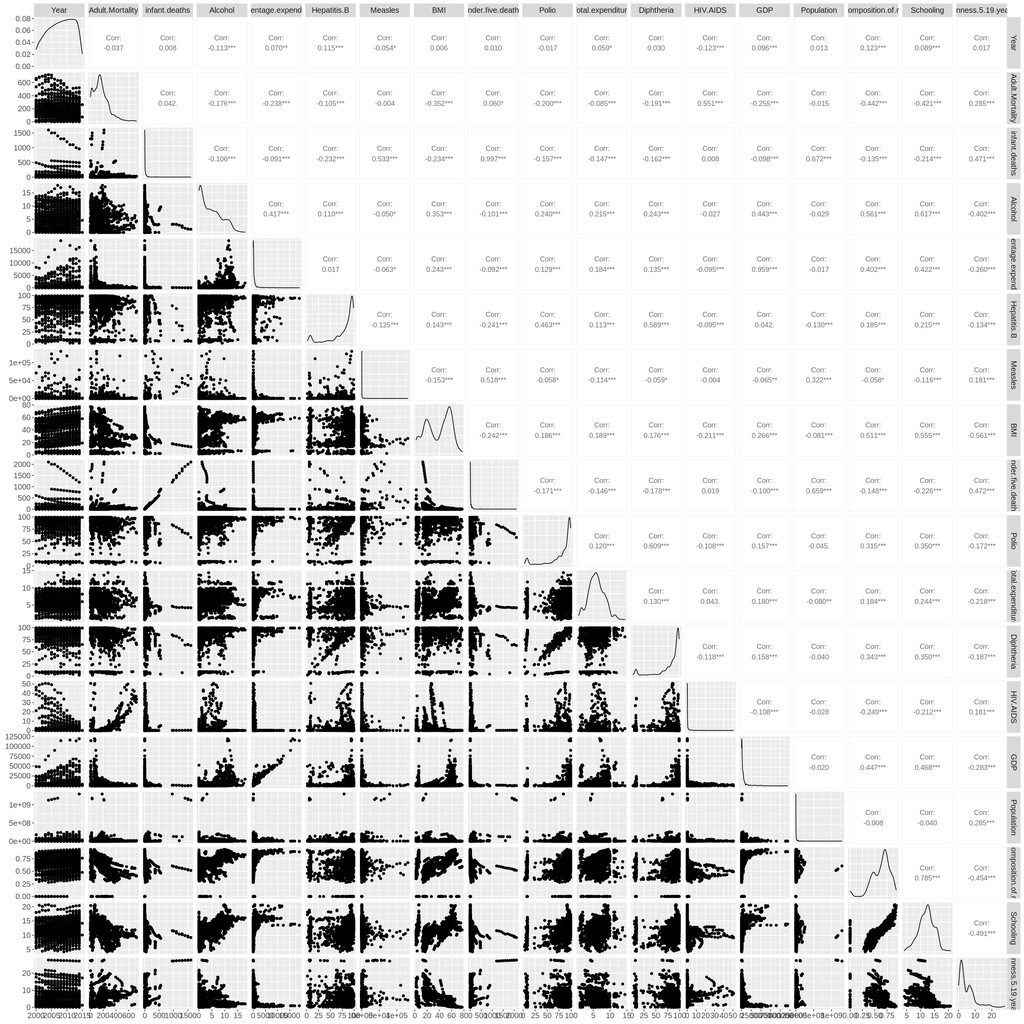

```r
options(repr.plot.width = 22,repr.plot.height= 22)
pair_plots
```

**Figure 3: GGpairs Plot of All Numeric Variables in the Dataset**

From Figure 3, there are some variables that have high correlation and linear relationship with others. For example, the variable `infant.deaths` have a very strong correlation with variable `under.five.deaths`, they have correlation of 0.997, which is a perfect correlation. This result suggest that we might need to remove one of the variable to avoid collinearity. There are also some variables appear to have no relationship, for example, the plot of variable `Year` and `Alcohol` show a cloud shape with no obvious pattern, indicating that there is no linear relationship between them. They have correlation of -0.113, which is very low.

We want to further explore these relationships, so we will create a heat map.

```r
# correlation matrix
corr_matrix_life <- numeric_variables %>%
  select(-Life.expectancy) %>%
  cor() %>%
  as.data.frame() %>%
  rownames_to_column("var1") %>%
  pivot_longer(-var1, names_to = "var2", values_to = "corr")
head(corr_matrix_life)
```

A tibble: 6 × 3

| var1 <chr> | var2 <chr> | corr <dbl> |
| --- | --- | --- |
| Year | Year | 1.000000000 |
| Year | Adult.Mortality | -0.037091782 |
| Year | infant.deaths | 0.008029128 |
| Year | Alcohol | -0.113364764 |
| Year | percentage.expenditure | 0.069553468 |
| Year | Hepatitis.B | 0.114897092 |

**Table 6: Top Rows of Correlation Matrix**

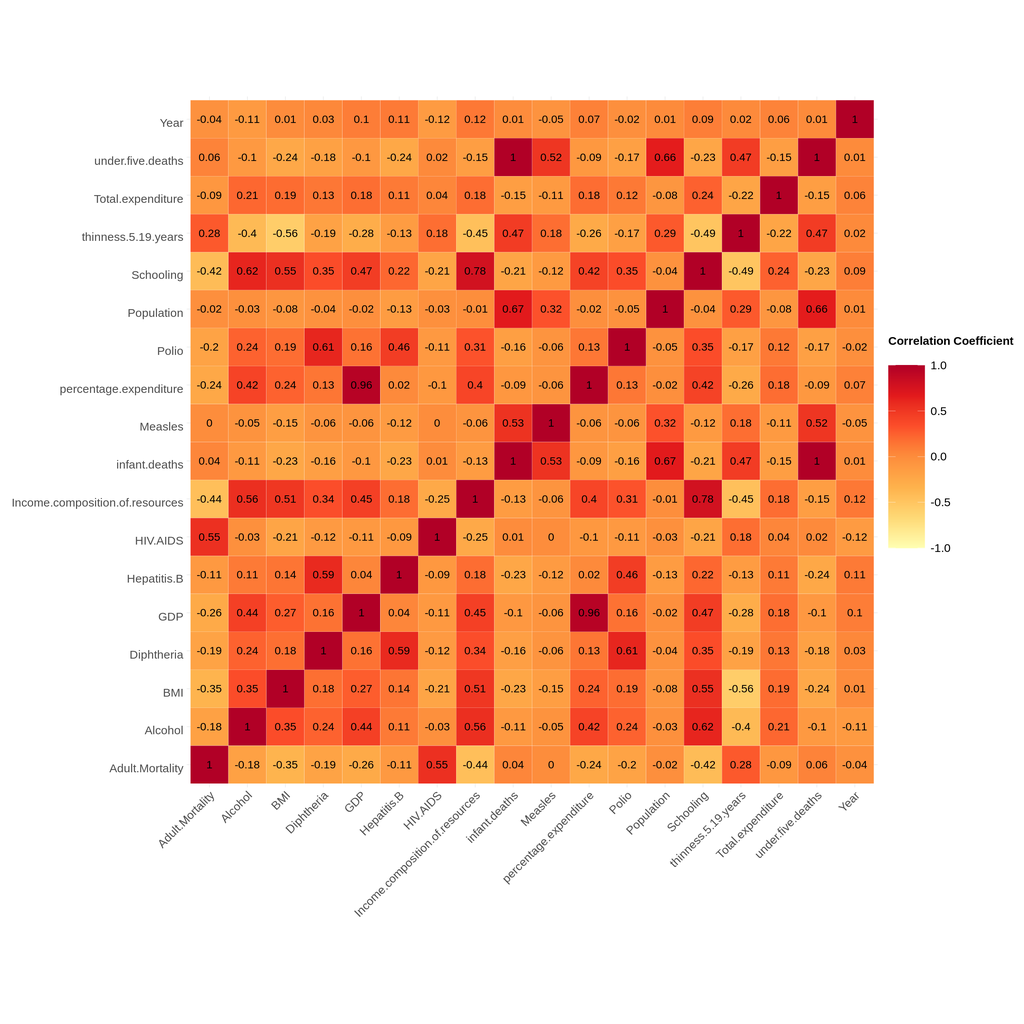

```r
# create heatmap correlation matrix based on correlation matrix
plot_corr_matrix_life <- corr_matrix_life %>%
  ggplot(aes(var1, var2)) +
  geom_tile(aes(fill = corr), color = "white") +
  scale_fill_distiller("Correlation Coefficient \n",
    palette = "YlOrRd",
    direction = 1, limits = c(-1, 1)
  ) +
  labs(x = "", y = "") +
  theme_minimal() +
  theme(
    axis.text.x = element_text(
      angle = 45, vjust = 1,
      size = 18, hjust = 1
    ),
    axis.text.y = element_text(
      vjust = 1,
      size = 18, hjust = 1
    ),
    legend.title = element_text(size = 18, face = "bold"),
    legend.text = element_text(size = 18),
    legend.key.size = unit(2, "cm")
  ) +
  coord_fixed() +
  geom_text(aes(var2, var1, label = round(corr, 2)), color = "black", size = 6)

plot_corr_matrix_life
```

**Figure 4: Heat Map of Correlations between all Numeric Variables**

Based on the heat map from Figure 4, we can see that `percentage.expenditure` and `GDP` have high correlation of value 0.96. Also, `infant.deaths` and `under.five.deaths` have correlation rounded to 1, which is a perfect positive correlation. This suggests that we might need to remove either `percentage.expenditure` or `GDP`, `infant.deaths` or `under.five.deaths`, in order to ensure our models meet the assumption of multicollinearity.

## Summary for results so far

- The original dataset contains 22 variables and 2938 observations in total.
- We remove rows with NA values, modify and remove columns, we have 20 variables and 1649 observations left for analysis.
- The response variable is `Life.expectancy` and there are 19 input variables including 18 numeric variables and 1 categorical variable.
- We need to remove some variables to alleviate multicollinearity.

## Plan for Next Section

- We fit a full model with our selected 19 input variables from the preprocessing above.
- We remove input variables that have large VIF to decrease multicollinearity in input variables.
- We check for assumptions of linear regression models including multicollinearity, normality, and heteroscedasticity.
- Also, we use Ridge regression to alleviate collinearity in input variables.
- We select our best model using cross-validation with Ridge regression (smallest lambda = best model).
- We calculate test RMSE of our models on unseen data (test set).
- We will have 3 models: full model, reduced model, and Ridge model, we want to pick the one with lowest test error.

## Methods and Results

### Data splitting

We split the data into 70% training set and 30% testing set.

```r
# splitting the data into 70% train and 30% test set.
set.seed(SEED)

life_tidy$ID <- 1:nrow(life_tidy)   # column 21 = ID
# head(life_tidy)

train_df <- sample_n(life_tidy, size = nrow(life_tidy) * 0.70,
  replace = FALSE
)

test_df <- anti_join(life_tidy,
  train_df,
  by = "ID"
)

nrow(train_df)
nrow(test_df)

head(train_df)
head(test_df)
```

1154

495

A data.frame: 6 × 21

|  | Year <int> | Status <fct> | Life.expectancy <dbl> | Adult.Mortality <int> | infant.deaths <int> | Alcohol <dbl> | percentage.expenditure <dbl> | Hepatitis.B <int> | Measles <int> | BMI <dbl> | ⋯ | Polio <int> | Total.expenditure <dbl> | Diphtheria <int> | HIV.AIDS <dbl> | GDP <dbl> | Population <dbl> | Income.composition.of.resources <dbl> | Schooling <dbl> | thinness.5.19.years <dbl> | ID <int> |
| --- | --- | --- | --- | --- | --- | --- | --- | --- | --- | --- | --- | --- | --- | --- | --- | --- | --- | --- | --- | --- | --- |
| 1 | 2007 | Developing | 66.0 | 259 | 2 | 0.16 | 9.087638 | 75 | 0 | 2.1 | ⋯ | 75 | 4.93 | 75 | 0.1 | 72.75931 | 64162 | 0.459 | 10.0 | 7.25 | 386 |
| 2 | 2012 | Developing | 74.2 | 13 | 1 | 7.71 | 158.257602 | 92 | 31 | 53.6 | ⋯ | 93 | 8.57 | 92 | 0.1 | 4142.86917 | 3825 | 0.749 | 13.4 | 2.70 | 554 |
| 3 | 2006 | Developing | 73.7 | 123 | 8 | 0.97 | 122.652333 | 83 | 517 | 48.5 | ⋯ | 83 | 3.78 | 8 | 0.1 | 1762.24617 | 18914977 | 0.636 | 11.4 | 6.35 | 1434 |
| 4 | 2000 | Developing | 72.4 | 149 | 4 | 0.54 | 23.371672 | 97 | 6187 | 26.0 | ⋯ | 98 | 3.40 | 98 | 0.1 | 445.17471 | 2318568 | 0.715 | 11.6 | 9.70 | 926 |
| 5 | 2008 | Developing | 73.5 | 146 | 14 | 4.45 | 978.070410 | 92 | 0 | 52.8 | ⋯ | 92 | 6.62 | 92 | 0.1 | 5433.72450 | 4491544 | 0.683 | 12.2 | 2.15 | 370 |
| 6 | 2009 | Developing | 81.0 | 72 | 2 | 8.40 | 864.949930 | 42 | 14 | 63.6 | ⋯ | 89 | 11.17 | 91 | 0.1 | 4773.45436 | 33628571 | 0.898 | 15.9 | 0.45 | 320 |

A data.frame: 6 × 21

|  | Year <int> | Status <fct> | Life.expectancy <dbl> | Adult.Mortality <int> | infant.deaths <int> | Alcohol <dbl> | percentage.expenditure <dbl> | Hepatitis.B <int> | Measles <int> | BMI <dbl> | ⋯ | Polio <int> | Total.expenditure <dbl> | Diphtheria <int> | HIV.AIDS <dbl> | GDP <dbl> | Population <dbl> | Income.composition.of.resources <dbl> | Schooling <dbl> | thinness.5.19.years <dbl> | ID <int> |
| --- | --- | --- | --- | --- | --- | --- | --- | --- | --- | --- | --- | --- | --- | --- | --- | --- | --- | --- | --- | --- | --- |
| 1 | 2013 | Developing | 59.9 | 268 | 66 | 0.01 | 73.219243 | 64 | 430 | 18.1 | ⋯ | 62 | 8.13 | 64 | 0.1 | 631.74498 | 31731688 | 0.470 | 9.9 | 17.70 | 3 |
| 2 | 2011 | Developing | 59.2 | 275 | 71 | 0.01 | 7.097109 | 68 | 3013 | 17.2 | ⋯ | 68 | 7.87 | 68 | 0.1 | 63.53723 | 2978599 | 0.454 | 9.5 | 18.20 | 5 |
| 3 | 2008 | Developing | 58.1 | 287 | 80 | 0.03 | 25.873925 | 64 | 1599 | 15.7 | ⋯ | 64 | 8.33 | 64 | 0.1 | 373.36112 | 2729431 | 0.433 | 8.7 | 18.85 | 8 |
| 4 | 2001 | Developing | 55.3 | 316 | 88 | 0.01 | 10.574728 | 63 | 8762 | 12.6 | ⋯ | 35 | 7.80 | 33 | 0.1 | 117.49698 | 2966463 | 0.340 | 5.9 | 2.25 | 15 |
| 5 | 2013 | Developing | 77.2 | 84 | 0 | 4.76 | 430.876979 | 99 | 0 | 56.5 | ⋯ | 99 | 5.66 | 99 | 0.1 | 4414.72314 | 289592 | 0.759 | 14.2 | 1.35 | 19 |
| 6 | 2012 | Developing | 76.9 | 86 | 0 | 5.14 | 412.443356 | 99 | 9 | 55.8 | ⋯ | 99 | 5.59 | 99 | 0.1 | 4247.61438 | 2941 | 0.752 | 14.2 | 1.35 | 20 |

**Table 7: Train Set and Test Set**

```r
# Remove variable "ID"
train_df <- train_df  %>% select(-ID)
test_df <- test_df  %>% select(-ID)
```

```r
colnames(train_df)
```

1. 'Year'

2. 'Status'

3. 'Life.expectancy'

4. 'Adult.Mortality'

5. 'infant.deaths'

6. 'Alcohol'

7. 'percentage.expenditure'

8. 'Hepatitis.B'

9. 'Measles'

10. 'BMI'

11. 'under.five.deaths'

12. 'Polio'

13. 'Total.expenditure'

14. 'Diphtheria'

15. 'HIV.AIDS'

16. 'GDP'

17. 'Population'

18. 'Income.composition.of.resources'

19. 'Schooling'

20. 'thinness.5.19.years'

```r
colnames(test_df) # 20 variables (input + response)
```

1. 'Year'

2. 'Status'

3. 'Life.expectancy'

4. 'Adult.Mortality'

5. 'infant.deaths'

6. 'Alcohol'

7. 'percentage.expenditure'

8. 'Hepatitis.B'

9. 'Measles'

10. 'BMI'

11. 'under.five.deaths'

12. 'Polio'

13. 'Total.expenditure'

14. 'Diphtheria'

15. 'HIV.AIDS'

16. 'GDP'

17. 'Population'

18. 'Income.composition.of.resources'

19. 'Schooling'

20. 'thinness.5.19.years'

### Full model

We estimate an additive MLR using all input variables in train_df.

```r
life_full_OLS <- lm(Life.expectancy ~ ., data = train_df)

tidy(life_full_OLS)
```

A tibble: 20 × 5

| term <chr> | estimate <dbl> | std.error <dbl> | statistic <dbl> | p.value <dbl> |
| --- | --- | --- | --- | --- |
| (Intercept) | 3.386221e+02 | 5.485181e+01 | 6.17339908 | 9.292659e-10 |
| Year | -1.421740e-01 | 2.739026e-02 | -5.19067583 | 2.481406e-07 |
| StatusDeveloping | -4.435148e-01 | 3.949272e-01 | -1.12302941 | 2.616627e-01 |
| Adult.Mortality | -1.580706e-02 | 1.124102e-03 | -14.06194514 | 1.609265e-41 |
| infant.deaths | 8.262982e-02 | 1.208721e-02 | 6.83613711 | 1.326204e-11 |
| Alcohol | -8.081161e-02 | 4.007245e-02 | -2.01663765 | 4.396870e-02 |
| percentage.expenditure | 3.218475e-04 | 2.357831e-04 | 1.36501493 | 1.725191e-01 |
| Hepatitis.B | -2.914028e-03 | 5.133862e-03 | -0.56760930 | 5.704126e-01 |
| Measles | -8.109094e-06 | 1.210061e-05 | -0.67013932 | 5.029054e-01 |
| BMI | 3.170021e-02 | 7.012795e-03 | 4.52033920 | 6.821539e-06 |
| under.five.deaths | -6.239134e-02 | 8.814655e-03 | -7.07813686 | 2.555278e-12 |
| Polio | 2.097608e-03 | 5.984131e-03 | 0.35052840 | 7.260073e-01 |
| Total.expenditure | 4.722680e-02 | 4.758511e-02 | 0.99247004 | 3.211800e-01 |
| Diphtheria | 1.451912e-02 | 7.144265e-03 | 2.03227612 | 4.235838e-02 |
| HIV.AIDS | -4.510690e-01 | 2.111510e-02 | -21.36239260 | 2.310159e-85 |
| GDP | 2.728336e-05 | 3.700940e-05 | 0.73720093 | 4.611527e-01 |
| Population | 4.007839e-11 | 2.073430e-09 | 0.01932951 | 9.845816e-01 |
| Income.composition.of.resources | 1.093984e+01 | 9.948040e-01 | 10.99697767 | 8.447247e-27 |
| Schooling | 8.961784e-01 | 7.019305e-02 | 12.76733710 | 5.623335e-35 |
| thinness.5.19.years | -5.624264e-02 | 3.343534e-02 | -1.68213183 | 9.281859e-02 |

**Table 8: R output of Full Model**

From Table 8, we can see that some variables have p-value very small, suggesting that the variables are significant.

We obtain the out-of-sample predictions of life expectancy on our unseen testing set using the additive MLR.

```r
life_test_pred_full_OLS <- predict(life_full_OLS, newdata = test_df)
head(life_test_pred_full_OLS)
```

**1**

62.4884582569829

**2**

61.9738598946461

**3**

61.1037405709211

**4**

58.260144882321

**5**

74.7896968028393

**6**

74.7568967671549

We compute the test RMSE(Root Mean Squared Error) for the predictions of `Life.expectancy` in `life_test_pred_full_OLS` with respect to the observed in the test set (test_df$Life.expectancy).

```r
life_R_MSE_models <- tibble(
  Model = "OLS Full Regression",
  R_MSE = rmse(
       preds = life_test_pred_full_OLS,
       actuals = test_df$Life.expectancy)  # squared difference bt predicted and real Y
)
life_R_MSE_models
```

A tibble: 1 × 2

| Model <chr> | R_MSE <dbl> |
| --- | --- |
| OLS Full Regression | 3.600359 |

**Table 9: RMSE of the Full Model**

The RMSE measures how well our model predicts the unseen data correctly. The lower the RMSE, the better a model. Our full model has RMSE value of 3.600359. This value seems small, but without other models to compare, we cannot say it is good enough.

### Assumptions of Linear Regression Models

It is very important to check whether our models meet the assumptions of linear regression model, if assumptions are violated, then the results from the model are not trustworthy.

There are 4 assumptions for linear regression models:

- Linear relation between input variables and response variable.
- Error terms are independent and identically distributed (check for Heteroscedasticity).
- Error terms are Normally distributed.
- Not severe Mulitcollinearity.

### Checking Heteroscedasticity for Full Model

We graphically diagnose heteroscedasticity by comparing the fitted values to the residuals.

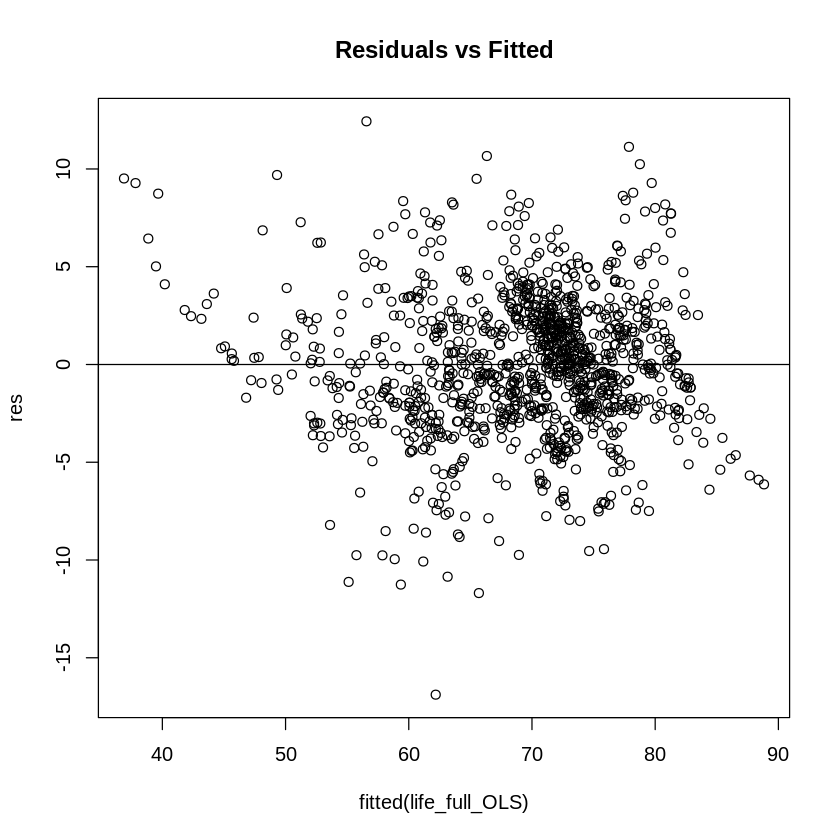

```r
options(repr.plot.width = 7, repr.plot.height = 7)

#get list of residuals
res <- resid(life_full_OLS)

#produce residual vs. fitted plot
plot(fitted(life_full_OLS), res, main = "Residuals vs Fitted")

#add a horizontal line at 0
abline(0,0)
```

**Figure 5: Residual vs Fitted Values Plot for Full Model**

### Checking Normality for Full Model

We assess the normality assumption via $Q$-$Q$ plot.

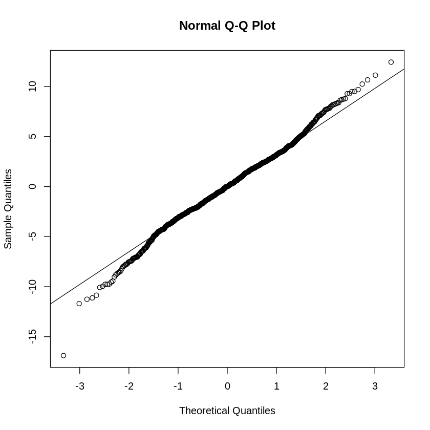

```r
options(repr.plot.width = 7, repr.plot.height = 7)

#create Q-Q plot for residuals
qqnorm(res)

#add a straight diagonal line to the plot
qqline(res)
```

**Figure 6: QQ Plot of Full Model**

QQ plot is useful for checking if the residuals follow a normal distribution. If the data values in the plot lie on the 45° degree line, then this indicates the error terms are normally distributed. The data values on our Figure 6 QQ plot lie near the 45° degree line, this indicates that the error terms are normally distributed.

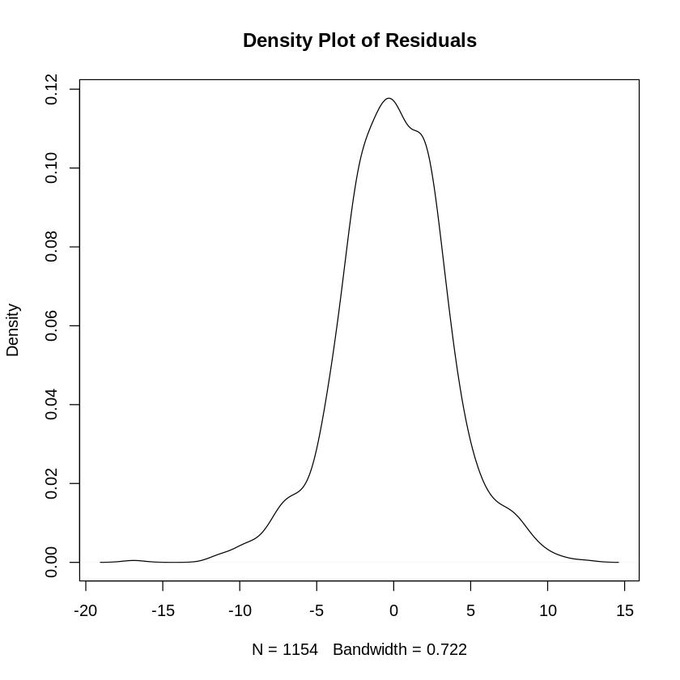

```r
options(repr.plot.width = 7, repr.plot.height = 7)

#Create density plot of residuals
plot(density(res),main = "Density Plot of Residuals")
```

**Figure 7: Density Plot of Full Model**

We create a density plot, which is useful for visually checking whether or not the residuals are normally distributed. A bell-shaped distribution of residuals indicates normality assumption of error terms is met.

### Checking for Multicollinearity for Full Model

We use the Variance Inflation Factor (VIF) to quantify multicollinearity in our input variables. VIF has values ranging from 1(no multicollinearity) to infinity. The larger the VIF, the more serious multicollinearity.

```r
VIF_MLR_life <- vif(life_full_OLS)
round(VIF_MLR_life, 3)     # some variables have very large VIF values
```

**Year**

1.145

**Status**

1.83

**Adult.Mortality**

1.841

**infant.deaths**

231.664

**Alcohol**

2.407

**percentage.expenditure**

14.247

**Hepatitis.B**

1.673

**Measles**

1.486

**BMI**

1.778

**under.five.deaths**

223.477

**Polio**

1.724

**Total.expenditure**

1.133

**Diphtheria**

2.166

**HIV.AIDS**

1.515

**GDP**

14.959

**Population**

2.113

**Income.composition.of.resources**

3.1

**Schooling**

3.618

**thinness.5.19.years**

2.184

We can see that `infant.deaths` and `under.five.deaths` have very high VIFs. We drop `infant.deaths` associated with the largest VIFs to deal with multicollinearity.

```r
red_MLR_life <- train_df  %>% select(-infant.deaths) %>%   # drop the input variables associated with the **largest** VIFs
                       lm(Life.expectancy ~ ., data =.)


red_MLR_life_results <- tidy(red_MLR_life) %>% mutate_if(is.numeric, round, 2)
red_MLR_life_results
```

A tibble: 19 × 5

| term <chr> | estimate <dbl> | std.error <dbl> | statistic <dbl> | p.value <dbl> |
| --- | --- | --- | --- | --- |
| (Intercept) | 366.16 | 55.79 | 6.56 | 0.00 |
| Year | -0.16 | 0.03 | -5.61 | 0.00 |
| StatusDeveloping | -0.47 | 0.40 | -1.17 | 0.24 |
| Adult.Mortality | -0.02 | 0.00 | -14.62 | 0.00 |
| Alcohol | -0.13 | 0.04 | -3.33 | 0.00 |
| percentage.expenditure | 0.00 | 0.00 | 1.25 | 0.21 |
| Hepatitis.B | 0.00 | 0.01 | -0.70 | 0.48 |
| Measles | 0.00 | 0.00 | 0.80 | 0.42 |
| BMI | 0.03 | 0.01 | 4.72 | 0.00 |
| under.five.deaths | 0.00 | 0.00 | -2.39 | 0.02 |
| Polio | 0.00 | 0.01 | 0.65 | 0.51 |
| Total.expenditure | 0.04 | 0.05 | 0.90 | 0.37 |
| Diphtheria | 0.02 | 0.01 | 2.73 | 0.01 |
| HIV.AIDS | -0.45 | 0.02 | -21.04 | 0.00 |
| GDP | 0.00 | 0.00 | 0.80 | 0.42 |
| Population | 0.00 | 0.00 | 1.30 | 0.19 |
| Income.composition.of.resources | 11.46 | 1.01 | 11.33 | 0.00 |
| Schooling | 0.92 | 0.07 | 12.92 | 0.00 |
| thinness.5.19.years | -0.03 | 0.03 | -0.99 | 0.32 |

**Table 10: R Output of Reduced Model**

From Table 10, we can see that some variables still have large p-value, suggesting that they are not significant.

We obtain the VIFs of `red_MLR_life`.

```r
VIF_red_MLR_life <- vif(red_MLR_life)
round(VIF_red_MLR_life, 3)
```

**Year**

1.139

**Status**

1.83

**Adult.Mortality**

1.818

**Alcohol**

2.318

**percentage.expenditure**

14.245

**Hepatitis.B**

1.672

**Measles**

1.418

**BMI**

1.775

**under.five.deaths**

3.186

**Polio**

1.72

**Total.expenditure**

1.133

**Diphtheria**

2.141

**HIV.AIDS**

1.515

**GDP**

14.957

**Population**

2.038

**Income.composition.of.resources**

3.081

**Schooling**

3.606

**thinness.5.19.years**

2.162

We can see that after we droped `infant.deaths`, the VIF of other input variables decreased. But `GDP` has the highest VIF value now, so we removed it and check VIF again.

```r
colnames(train_df)
```

1. 'Year'

2. 'Status'

3. 'Life.expectancy'

4. 'Adult.Mortality'

5. 'infant.deaths'

6. 'Alcohol'

7. 'percentage.expenditure'

8. 'Hepatitis.B'

9. 'Measles'

10. 'BMI'

11. 'under.five.deaths'

12. 'Polio'

13. 'Total.expenditure'

14. 'Diphtheria'

15. 'HIV.AIDS'

16. 'GDP'

17. 'Population'

18. 'Income.composition.of.resources'

19. 'Schooling'

20. 'thinness.5.19.years'

```r
red_MLR_life_2 <- train_df  %>% select(-GDP,-infant.deaths) %>%
                       lm(Life.expectancy ~ ., data =.)
# drop the input variables associated with the **largest** VIFs

red_MLR_life_results_2 <- tidy(red_MLR_life_2) %>% mutate_if(is.numeric, round, 2)
red_MLR_life_results_2
```

A tibble: 18 × 5

| term <chr> | estimate <dbl> | std.error <dbl> | statistic <dbl> | p.value <dbl> |
| --- | --- | --- | --- | --- |
| (Intercept) | 362.16 | 55.56 | 6.52 | 0.00 |
| Year | -0.15 | 0.03 | -5.57 | 0.00 |
| StatusDeveloping | -0.48 | 0.40 | -1.20 | 0.23 |
| Adult.Mortality | -0.02 | 0.00 | -14.63 | 0.00 |
| Alcohol | -0.13 | 0.04 | -3.31 | 0.00 |
| percentage.expenditure | 0.00 | 0.00 | 6.30 | 0.00 |
| Hepatitis.B | 0.00 | 0.01 | -0.65 | 0.52 |
| Measles | 0.00 | 0.00 | 0.80 | 0.42 |
| BMI | 0.03 | 0.01 | 4.71 | 0.00 |
| under.five.deaths | 0.00 | 0.00 | -2.38 | 0.02 |
| Polio | 0.00 | 0.01 | 0.69 | 0.49 |
| Total.expenditure | 0.04 | 0.05 | 0.83 | 0.40 |
| Diphtheria | 0.02 | 0.01 | 2.71 | 0.01 |
| HIV.AIDS | -0.45 | 0.02 | -21.03 | 0.00 |
| Population | 0.00 | 0.00 | 1.29 | 0.20 |
| Income.composition.of.resources | 11.50 | 1.01 | 11.39 | 0.00 |
| Schooling | 0.93 | 0.07 | 13.03 | 0.00 |
| thinness.5.19.years | -0.03 | 0.03 | -1.01 | 0.31 |

**Table 11: Reduced Model with Removed Variables Corresponding to Large VIF**

```r
VIF_red_MLR_life_2 <- vif(red_MLR_life_2)
round(VIF_red_MLR_life_2, 3) # 17 input variables left
```

**Year**

1.13

**Status**

1.827

**Adult.Mortality**

1.818

**Alcohol**

2.316

**percentage.expenditure**

1.449

**Hepatitis.B**

1.665

**Measles**

1.418

**BMI**

1.774

**under.five.deaths**

3.185

**Polio**

1.718

**Total.expenditure**

1.124

**Diphtheria**

2.138

**HIV.AIDS**

1.514

**Population**

2.038

**Income.composition.of.resources**

3.074

**Schooling**

3.582

**thinness.5.19.years**

2.161

This time, after dropping GDP and infant.deaths, we can see that the remaining 17 input variables have small VIF, indicating low level of Multicollinearity. We now compare the test RMSE(Root Mean Squared Error) of our `red_MLR_life_2` model and the full model `life_full_OLS` on unseen data.

```r
life_test_pred_red_MLR <- predict(red_MLR_life_2, newdata = test_df)
head(life_test_pred_red_MLR)
```

**1**

62.4570842198302

**2**

62.0212841088459

**3**

61.123792823388

**4**

57.8054472062766

**5**

74.9917582196985

**6**

74.9459178781647

```r
life_R_MSE_red_VIF_models <- tibble(
  Model = "Reduced Regression(VIF)",
  R_MSE = rmse(
       preds = life_test_pred_red_MLR,
       actuals = test_df$Life.expectancy)  # squared difference bt predicted and real Y
)
full_vs_redVIF_testRMSE <- rbind(life_R_MSE_models,life_R_MSE_red_VIF_models)
full_vs_redVIF_testRMSE
```

A tibble: 2 × 2

| Model <chr> | R_MSE <dbl> |
| --- | --- |
| OLS Full Regression | 3.600359 |
| Reduced Regression(VIF) | 3.679267 |

**Table 12: Comparison between RMSE of Full Model and Reduced Model**

From the test RMSE of the full model and reduced model above, we can see that the reduced model has slightly larger RMSE than that of the full model, meaning that the full model has slightly better predictive performance on unseen data. But because the reduced model does not contain variables with large VIF, we keep the reduced model.

### Checking Heteroscedasticity & Normality for Reduced Model

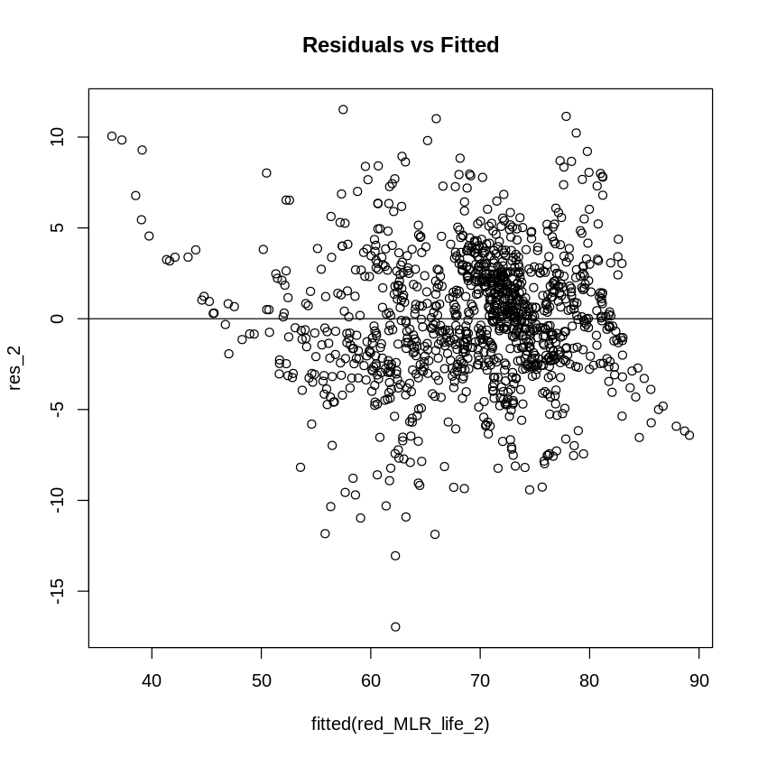

```r
options(repr.plot.width = 7, repr.plot.height = 7)

#get list of residuals
res_2 <- resid(red_MLR_life_2)

#produce residual vs. fitted plot
plot(fitted(red_MLR_life_2), res_2, main = "Residuals vs Fitted")

#add a horizontal line at 0
abline(0,0)
```

**Figure 8: Residual vs Fitted Values Plot for Reduced Model**

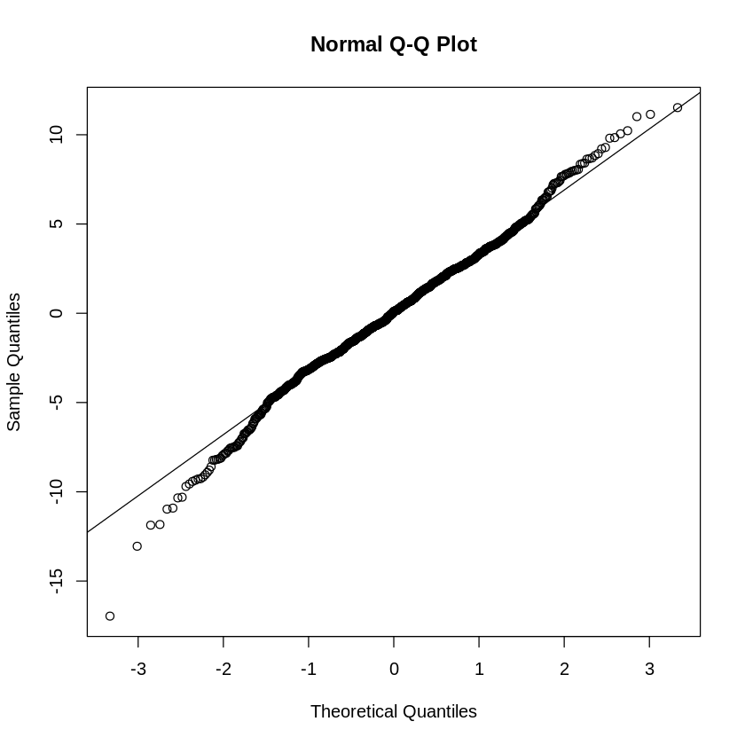

```r
options(repr.plot.width = 7, repr.plot.height = 7)

#create Q-Q plot for residuals
qqnorm(res_2)

#add a straight diagonal line to the plot
qqline(res_2)
```

**Figure 9: QQ Plot of Reduced Model**

The data values on our Figure 9 QQ plot lie near the 45° degree line, this indicates that the error terms are normally distributed.

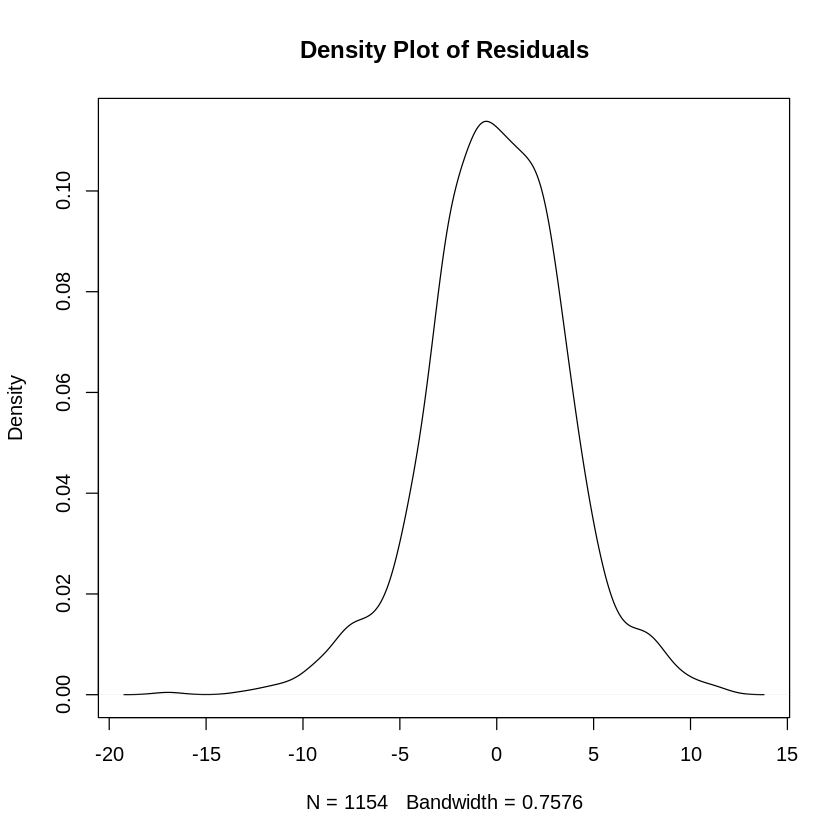

```r
options(repr.plot.width = 7, repr.plot.height = 7)

#Create density plot of residuals
plot(density(res_2),main = "Density Plot of Residuals")
```

**Figure 10: Density Plot of Reduced Model**

The density plot of Figure 10 above shows bell-shaped distribution of residuals, this indicates normality assumption of error terms is met.

Since our reduced model meets all assumptions of Linear Regression Models, results from the reduced model are trustworthy and reliable, and we have a lot of confidence in our model.

## Model Improvement: Cross-Validation with Ridge Regression

```r
colnames(train_df) # 20 total variables
```

1. 'Year'

2. 'Status'

3. 'Life.expectancy'

4. 'Adult.Mortality'

5. 'infant.deaths'

6. 'Alcohol'

7. 'percentage.expenditure'

8. 'Hepatitis.B'

9. 'Measles'

10. 'BMI'

11. 'under.five.deaths'

12. 'Polio'

13. 'Total.expenditure'

14. 'Diphtheria'

15. 'HIV.AIDS'

16. 'GDP'

17. 'Population'

18. 'Income.composition.of.resources'

19. 'Schooling'

20. 'thinness.5.19.years'

```r
# Build matrix and vector required by `glmnet`
#    separate y_train from x_train   # 20 input variables,
glm_X_train <- model.matrix(object = Life.expectancy ~ Year+Status+Adult.Mortality+
                            Alcohol+percentage.expenditure+Hepatitis.B+Measles+BMI+
                            under.five.deaths+Polio+Total.expenditure+Diphtheria+
                            HIV.AIDS+Population+thinness.5.19.years+
                            Income.composition.of.resources+Schooling+GDP+infant.deaths,
  data = train_df)[, -1]

glm_Y_train <- train_df[, "Life.expectancy"]
```

```r
glm_X_test <-
    model.matrix(object = Life.expectancy ~ Year+Status+Adult.Mortality+
                            Alcohol+percentage.expenditure+Hepatitis.B+Measles+BMI+
                            under.five.deaths+Polio+Total.expenditure+Diphtheria+
                            HIV.AIDS+Population+thinness.5.19.years+
                            Income.composition.of.resources+Schooling+GDP+infant.deaths,
  data = test_df)[, -1]
```

```r
head(glm_X_train) # 19 input variables
```

A matrix: 6 × 19 of type dbl

|  | Year | StatusDeveloping | Adult.Mortality | Alcohol | percentage.expenditure | Hepatitis.B | Measles | BMI | under.five.deaths | Polio | Total.expenditure | Diphtheria | HIV.AIDS | Population | thinness.5.19.years | Income.composition.of.resources | Schooling | GDP | infant.deaths |
| --- | --- | --- | --- | --- | --- | --- | --- | --- | --- | --- | --- | --- | --- | --- | --- | --- | --- | --- | --- |
| 1 | 2007 | 1 | 259 | 0.16 | 9.087638 | 75 | 0 | 2.1 | 2 | 75 | 4.93 | 75 | 0.1 | 64162 | 7.25 | 0.459 | 10.0 | 72.75931 | 2 |
| 2 | 2012 | 1 | 13 | 7.71 | 158.257602 | 92 | 31 | 53.6 | 1 | 93 | 8.57 | 92 | 0.1 | 3825 | 2.70 | 0.749 | 13.4 | 4142.86917 | 1 |
| 3 | 2006 | 1 | 123 | 0.97 | 122.652333 | 83 | 517 | 48.5 | 10 | 83 | 3.78 | 8 | 0.1 | 18914977 | 6.35 | 0.636 | 11.4 | 1762.24617 | 8 |
| 4 | 2000 | 1 | 149 | 0.54 | 23.371672 | 97 | 6187 | 26.0 | 5 | 98 | 3.40 | 98 | 0.1 | 2318568 | 9.70 | 0.715 | 11.6 | 445.17471 | 4 |
| 5 | 2008 | 1 | 146 | 4.45 | 978.070410 | 92 | 0 | 52.8 | 16 | 92 | 6.62 | 92 | 0.1 | 4491544 | 2.15 | 0.683 | 12.2 | 5433.72450 | 14 |
| 6 | 2009 | 1 | 72 | 8.40 | 864.949930 | 42 | 14 | 63.6 | 2 | 89 | 11.17 | 91 | 0.1 | 33628571 | 0.45 | 0.898 | 15.9 | 4773.45436 | 2 |

**Table 13: Train Set in Matrix Form Ready for cv.glmnet**

```r
head(glm_X_test)
```

A matrix: 6 × 19 of type dbl

|  | Year | StatusDeveloping | Adult.Mortality | Alcohol | percentage.expenditure | Hepatitis.B | Measles | BMI | under.five.deaths | Polio | Total.expenditure | Diphtheria | HIV.AIDS | Population | thinness.5.19.years | Income.composition.of.resources | Schooling | GDP | infant.deaths |
| --- | --- | --- | --- | --- | --- | --- | --- | --- | --- | --- | --- | --- | --- | --- | --- | --- | --- | --- | --- |
| 1 | 2013 | 1 | 268 | 0.01 | 73.219243 | 64 | 430 | 18.1 | 89 | 62 | 8.13 | 64 | 0.1 | 31731688 | 17.70 | 0.470 | 9.9 | 631.74498 | 66 |
| 2 | 2011 | 1 | 275 | 0.01 | 7.097109 | 68 | 3013 | 17.2 | 97 | 68 | 7.87 | 68 | 0.1 | 2978599 | 18.20 | 0.454 | 9.5 | 63.53723 | 71 |
| 3 | 2008 | 1 | 287 | 0.03 | 25.873925 | 64 | 1599 | 15.7 | 110 | 64 | 8.33 | 64 | 0.1 | 2729431 | 18.85 | 0.433 | 8.7 | 373.36112 | 80 |
| 4 | 2001 | 1 | 316 | 0.01 | 10.574728 | 63 | 8762 | 12.6 | 122 | 35 | 7.80 | 33 | 0.1 | 2966463 | 2.25 | 0.340 | 5.9 | 117.49698 | 88 |
| 5 | 2013 | 1 | 84 | 4.76 | 430.876979 | 99 | 0 | 56.5 | 1 | 99 | 5.66 | 99 | 0.1 | 289592 | 1.35 | 0.759 | 14.2 | 4414.72314 | 0 |
| 6 | 2012 | 1 | 86 | 5.14 | 412.443356 | 99 | 9 | 55.8 | 1 | 99 | 5.59 | 99 | 0.1 | 2941 | 1.35 | 0.752 | 14.2 | 4247.61438 | 0 |

**Table 14: Test Set in Matrix Form Ready for cv.glmnet**

### Lambda hyperparameter optimization with Cross-Validation

Next, we find the optimal value of $\lambda$ (that corresponds to the best predictive performance) by carrying out a 10-folds cross validation.

```r
set.seed(SEED)

life_cv_lambda_ridge <- cv.glmnet(
  x = glm_X_train, y = glm_Y_train,
  alpha = 0,
  nfolds = 10, # add k-fold: 10-folds
  lambda = exp(seq(-15, 5, 0.1))
)
# life_cv_lambda_ridge$lambda.min
```

We visualize the results and find the value of $\lambda$ that minimizes the CV error and its associated mean squared error (MSE).

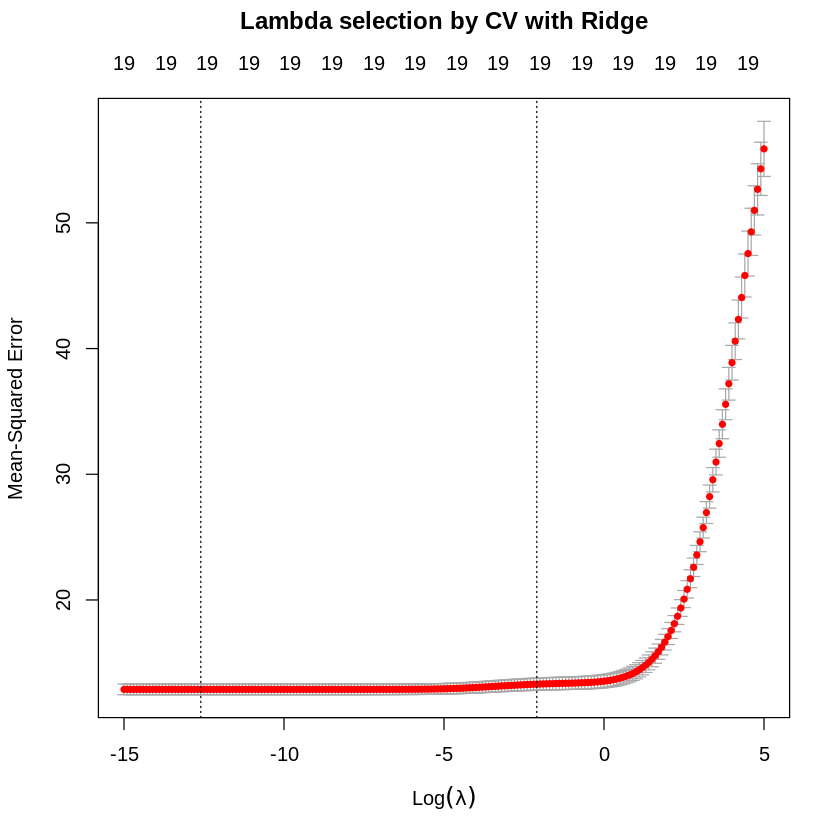

```r
options(repr.plot.width = 7, repr.plot.height = 7)
plot(life_cv_lambda_ridge, main = "Lambda selection by CV with Ridge\n\n")
```

**Figure 11: Lambda Value Plot for Finding Optimal Value**

```r
# the lambda value corresponds to the lowest CV error:
#   we will use this opimal lambda to build final model.
life_lambda_min_MSE_ridge <- life_cv_lambda_ridge$lambda.min
life_lambda_min_MSE_ridge  # should name it best.lam

# log(life_lambda_min_MSE_ridge)
```

3.37201523413918e-06

The `life_lambda_min_MSE_ridge` value above is the optimal lambda value that corresponds to the lowest CV error. We will use `life_lambda_min_MSE_ridge` to produce our final model.

## Final Model

We build our final model with optimal $\lambda$ value from cross-validaiton.

```r
# ridge
life_ridge_min <- glmnet(
  x = glm_X_train, y = glm_Y_train,
  alpha = 0,
  lambda = life_lambda_min_MSE_ridge
)
```

## Prediction and Accuracy

We use the model to predict the response variable on the test set.

```r
# ridge predictions

life_test_pred_ridge_min <- predict(life_ridge_min, newx = glm_X_test)
```

```r
life_R_MSE_ridge_min <- tibble(
  Model = "Ridge Regression with minimum MSE",
  R_MSE = rmse(
       preds = life_test_pred_ridge_min,
       actuals = test_df$Life.expectancy)  # squared difference bt predicted and real Y
)
life_R_MSE_ridge_min
```

A tibble: 1 × 2

| Model <chr> | R_MSE <dbl> |
| --- | --- |
| Ridge Regression with minimum MSE | 3.602049 |

**Table 15: RMSE of Ridge Model with Optimal Lmabda Value**

```r
# comparison with full and reduced models:
rbind(life_R_MSE_models,life_R_MSE_red_VIF_models,life_R_MSE_ridge_min)
```

A tibble: 3 × 2

| Model <chr> | R_MSE <dbl> |
| --- | --- |
| OLS Full Regression | 3.600359 |
| Reduced Regression(VIF) | 3.679267 |
| Ridge Regression with minimum MSE | 3.602049 |

**Table 16: Comparison of RMSE between Our 3 Models**

We compare the RMSE of our full model, reduced model, and Ridge model. The Ridge model has second lowest RMSE. But since ridge regression can alleviate collinearity, we still choose the ridge model. Also, the full model does not meet the assumption of multicollinearity, so this makes it a less trustworthy model.

## Discussion and Conclusion

**Summary and Impact**

Through our study, we found 3 models, they are the full model, reduced model, and ridge regression model. They all have very close RMSE, which is a measure of a model's performance on predictions of unseen data. The full model has the lowest RMSE, but it violates the assumption of multicollinearity, so this decreases its reliability. The reduced model meets all assumptions of linear regression model, but it has higher RMSE than our ridge model. Our ridge regression model will be our best predictive model, because it has the second lowest RMSE and ridge regression can alleviate collinearity.

These findings allow us to make prediction on people’s life span or expectancy. Also, being able to make predictions on life expectancy allows governments or institutes to better design plans for public infrastructure and communities.

**Improvements**

The model could be improved by including more data points and variables. The raw dataset contains many rows with NA values and we need to remove these rows, and this decreases the number of avaliable data points for us to do analysis. Even though including more observations might be expensive, the resulting predictive model might be more accurate.

We used ridge regression, which is a shrinkage method that does not shrink parameters to 0 and select variables. We would like to try lasso regression in the future, because lasso does select variables and this might help reduce costs in building models.

In the future, we want to make inference on how to improve people’s life span which might potentially increase citizens’ satisfaction in life. Inference involves deeper understanding of input variables and their relationships with response variable.

**Further Research**

For future studies and research, we want to investigate the combine effects of the input variables on the response variable by including interaction terms in our models. We also want to find some potential confounding variables.

## References

- Bushnik, T., Tjepkema, M., Martel, L. (2018). Health-adjusted life expectancy in Canada. Statistics Canada. https://www150.statcan.gc.ca/n1/pub/82-003-x/2018004/article/54950-eng.htm
- Gorina, Y., Hoyert, D., Lentzne, H., Goulding, M. (2006). Trends in causes of death among older persons in the United States. Aging Trends, No 6. Hyattsville, Maryland: National Center for Health Statistics. https://www.cdc.gov/nchs/data/ahcd/agingtrends/06olderpersons.pdf
- MacroTrends. (n.d.). World death rate 1950-2022. https://www.macrotrends.net/countries/WLD/world/death-rate
- O'Connor, S. (2022). Do you really want to live to be 100? Subscribe to read | Financial Times. https://www.ft.com/content/d79fb928-7adf-4a76-baff-6c7a533149d6
- Rajarshi, K. (n.d.) “Life Expectancy (WHO) | Kaggle.” Kaggle: Your Machine Learning and Data Science Community. https://www.kaggle.com/datasets/kumarajarshi/life-expectancy-who?resource=download.